# PG-NYC slides

## IMPLEMENTACIÓN DE UN SERVICIO DE TRANSPORTE EN LA CIUDAD DE NUEVA YORK

### ANÁLISIS PRELIMINAR

### Fabricio Barrera Edgardo Mattos Lautaro Pérez Jaime Sarmiento

## CONSIDERACIONES INICIALES

- No se toman en cuenta beneficios tributarios por uso de tecnologías limpias.
- Se toma un consumo de gasolina promedio: 22.6 millas por galón.
- Precio promedio de gasolina: $ 2.611
- Se trabaja únicamente con el dataset de Yellow Taxis correspondiente a Enero de 2018.

## OBJETIVO GENERAL

- Establecer la viabilidad del negocio

## OBJETIVOS ESPECÍFICOS

- Implementar un Data Lake on-premise para el negocio.
- Crear y automatizar dashboards para la toma de decisiones del negocio.
- Implementar un modelo de Machine Learning que ayude a predecir los momentos de alta demanda/retorno esperado por mes.
- Automatizar los procesos de ETL y procesamiento de datos.
- Determinar los recorridos más rentables.
- Determinar las horas de mayor demanda.
- Determinar la influencia que tienen las condiciones ambientales sobre la demanda.
- Determinar la cantidad mínima de taxis para suplir la demanda.
- Determinar cuáles son los distritos y zonas más rentables en la ciudad.
- Determinar el margen de ganancia diario.

## METRICAS

- Viajes inter e intra distrito
- Distritos con mayor/menor cantidad de viajes
- Distancia promedio de viaje
- Días de la semana y semana con mayor cantidad de viajes
- Margen de ganancia por milla recorrida
- Duración promedio de viaje
- Zonas TLC con mayor/menor movimiento

## ALCANCE

- Uso conjunto de datasets de Yellow Taxis y Clima.
- La información se complementa con datos de consumo de gasolina provistos por la oficina de sostenibilidad de la alcaldía de Nueva York.
- El estudio tiene en cuenta que la empresa operará con una flota propia de vehículos.

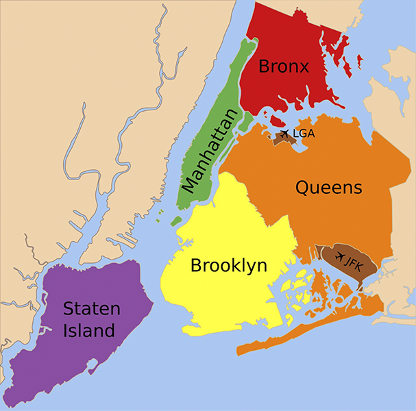

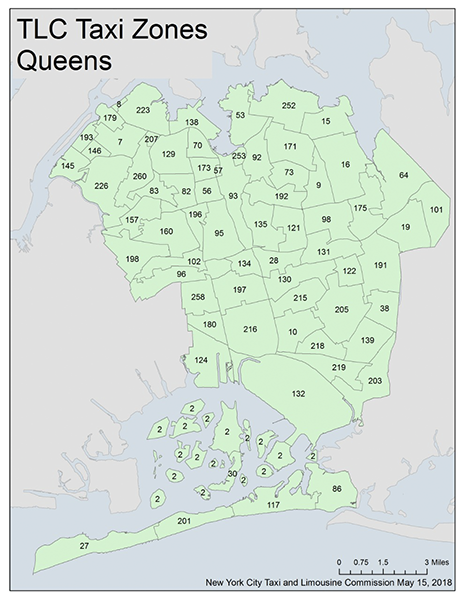

## FUERA DE ALCANCE

- No se tiene en cuenta la información correspondiente a Green Taxis ni plataformas como Uber y Lyft.
- Las propinas se consideran irrelevantes para el modelo .
- No se estudia el impacto ambiental ni los beneficios por uso de tecnologías limpias.
- No se hará uso de tecnología en la nube para la implementación.

## SOLUCION PROPUESTA

### Stack Tecnológico

- MinIO
- Apache Airflow
- Python
- PostgreSQL
- Docker
- PowerBI

## METODOLOGIA DE TRABAJO

El proyecto se desarrollará en 3 etapas:

- Etapa 1: Modelo Dimensional
- Etapa 2: Visualización
- Etapa 3: Deployment

## ENTREGABLES

Al finalizar el proyecto el cliente recibirá:

- Data Lake implementado con la información inicial debidamente cargada.
- Dashboards y Reportes para toma de decisiones
- Modelo predictivo
- Documentación relacionada con todas las etapas de proyecto